# Tidying data, with solutions (ds4psy)

Hansjörg Neth, SPDS, uni.kn

2019 05 22

# Introduction

This file contains **essential commands** from [Chapter 12: Tidy data](https://r4ds.had.co.nz/tidy-data.html) of the textbook [r4ds](http://r4ds.had.co.nz) and corresponding examples and exercises. A command is considered “essential” when you really need to *know* it and need to know *how to use* it to succeed in this course.

All [ds4psy](http://rpository.com/ds4psy/) essentials so far:

| Nr. | Topic |
| --- | --- |
| 0. | [Syllabus](http://rpository.com/ds4psy/) |
| 1. | [Basic R concepts and commands](http://rpository.com/ds4psy/essentials/basics.html) |
| 2. | [Visualizing data](http://rpository.com/ds4psy/essentials/visualize.html) |
| 3. | [Transforming data](http://rpository.com/ds4psy/essentials/transform.html) |
| 4. | [Exploring data (EDA)](http://rpository.com/ds4psy/essentials/explore.html) |
| 5. | [Tibbles](http://rpository.com/ds4psy/essentials/tibbles.html) |
| 6. | [Importing data](http://rpository.com/ds4psy/essentials/import.html) |
| 7. | **Tidying data** [*](http://rpository.com/ds4psy/essentials/tidy.html) |
| 8. | [Joining data](http://rpository.com/ds4psy/essentials/join.html) |
| 9. | [Functions](http://rpository.com/ds4psy/essentials/function.html) |
| 10. | [Iteration](http://rpository.com/ds4psy/essentials/iteration.html) |
| +. | [Datasets](http://rpository.com/ds4psy/essentials/datasets.html) |

## Course coordinates

- PSY-15150, at the [University of Konstanz](https://www.uni-konstanz.de/) by [Hansjörg Neth](http://neth.de/) (h.neth@uni.kn, [SPDS](https://www.spds.uni-konstanz.de/), office D507).
- Summer 2019: Mondays, 15:15–16:45, D435.
- Links to current [course syllabus](http://rpository.com/ds4psy/) | [ZeUS](https://zeus.uni-konstanz.de:443/hioserver/pages/startFlow.xhtml?_flowId=detailView-flow&unitId=5101&periodId=179&navigationPosition=hisinoneLehrorganisation,examEventOverviewOwn) | [Ilias](https://ilias.uni-konstanz.de/ilias/goto_ilias_uni_crs_863036.html)
- [ds4psy](https://bookdown.org/hneth/ds4psy/%3E) essentials and WPAs

## Preparations

Create an R script (`.R`) or an R-Markdown file (`.Rmd`) and load the R packages of the `tidyverse`. (**Hint:** Structure your script by inserting spaces, meaningful comments, and sections.)

```r
## Tidy data | ds4psy
## 2019 05 22
## ----------------------------

## Preparations: ----------

library(tidyverse)

## 1. Topic: ----------

# etc.

## End of file (eof). ----------
```

To use [R Markdown](https://rmarkdown.rstudio.com), create a corresponding file and save it with the `.Rmd` extension (e.g., by selecting `File > New File > R Markdown`). For instructions on combining text and code, see [Chapter 27: R Markdown](https://r4ds.had.co.nz/r-markdown.html) of our textbook, or use one of the following templates:

- minimal template: `rmd_template_s` [in .Rmd | .html format]
- medium template: `rmd_template_m` [in .Rmd | .html format]
- explicit explanations: `Rmarkdown_basics` [in .Rmd | .html format]

**Hint:** Try to *knit* your `.Rmd` file immediately after saving it and marvel at the beauty of the resulting `.html`-file. If this works, keep doing this routinely from now on, putting all your R-code into code chunks, and any text (like headings or conclusions) that describes or explains what you are doing outside of them. From now on, you can share your `.html` output files, rather than your `.Rmd` source files when showing off your R and data science skills.

# Tidy data

The notion of *tidy data* lies at the core of the tidyverse. The same dataset can be formatted in a variety of formats. Even though they can contain the same data, different formats differ in how easy or hard they are to work with (e.g., for specific analyses or plots). Tidy data is formatted in a simple and straightforward way, which makes it immensely practical (e.g., easy to understand, analyze, and transform into other formats).

Before defining the notion of tidy data, we first compare and contrast different sets of rectangular data that contain the same information.

## Tabular data

In R, rectangular data is often organized in *tibbles* or *data frames*. Importantly, each column is a vector (of a particular type) that contains the values of a variable. Thus, whereas every column must be of one type, every row can contain values of different variables and types.

The same set of data (values of variables) can be organised in many different ways. For instance, the following tables (or tibbles) all provide the number of TB cases documented by the World Health Organization in 3 countries (Afghanistan, Brazil, and China) in 2 years (1999 and 2000):

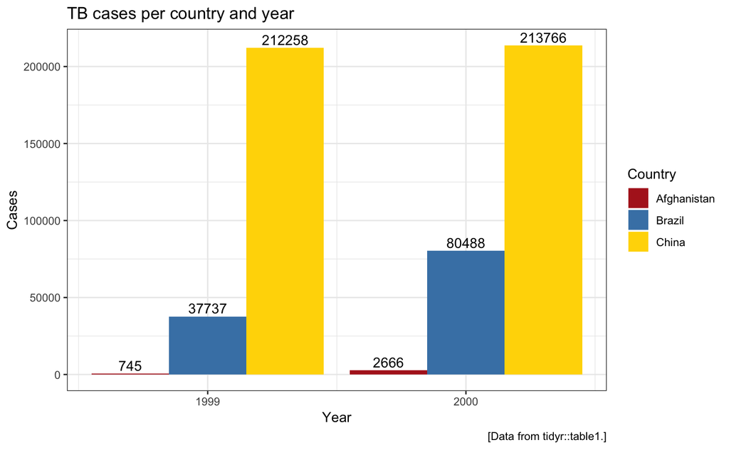

```r
library(tidyverse)

## Example of the same data organised in 4 different ways:
# ?table1 # for semantics and source of data

knitr::kable(tidyr::table1, caption = "Example of table1: Tidy data.")
```

Example of table1: Tidy data.

| country | year | cases | population |
| --- | --- | --- | --- |
| Afghanistan | 1999 | 745 | 19987071 |
| Afghanistan | 2000 | 2666 | 20595360 |
| Brazil | 1999 | 37737 | 172006362 |
| Brazil | 2000 | 80488 | 174504898 |
| China | 1999 | 212258 | 1272915272 |
| China | 2000 | 213766 | 1280428583 |

```r
dim(tidyr::table1)  #  6 x 4: 2 IVs, 2 DVs.
```

```
#> [1] 6 4
```

```r
knitr::kable(tidyr::table2, caption = "Example of table2: count contains 2 DVs.")
```

Example of table2: count contains 2 DVs.

| country | year | type | count |
| --- | --- | --- | --- |
| Afghanistan | 1999 | cases | 745 |
| Afghanistan | 1999 | population | 19987071 |
| Afghanistan | 2000 | cases | 2666 |
| Afghanistan | 2000 | population | 20595360 |
| Brazil | 1999 | cases | 37737 |
| Brazil | 1999 | population | 172006362 |
| Brazil | 2000 | cases | 80488 |
| Brazil | 2000 | population | 174504898 |
| China | 1999 | cases | 212258 |
| China | 1999 | population | 1272915272 |
| China | 2000 | cases | 213766 |
| China | 2000 | population | 1280428583 |

```r
dim(tidyr::table2)  #  12 x 4: 3 IVs, 1 DV.
```

```
#> [1] 12  4
```

```r
knitr::kable(tidyr::table3, caption = "Example of table3: rate contains 2 DVs.")
```

Example of table3: rate contains 2 DVs.

| country | year | rate |
| --- | --- | --- |
| Afghanistan | 1999 | 745/19987071 |
| Afghanistan | 2000 | 2666/20595360 |
| Brazil | 1999 | 37737/172006362 |
| Brazil | 2000 | 80488/174504898 |
| China | 1999 | 212258/1272915272 |
| China | 2000 | 213766/1280428583 |

```r
dim(tidyr::table3)  #  6 x 3: 2 IVs, 1 column with 2 DVs.
```

```
#> [1] 6 3
```

```r
knitr::kable(tidyr::table4a, caption = "Example of table4a: 1999 and 2000 contain same DV (cases).")
```

Example of table4a: 1999 and 2000 contain same DV (cases).

| country | 1999 | 2000 |
| --- | --- | --- |
| Afghanistan | 745 | 2666 |
| Brazil | 37737 | 80488 |
| China | 212258 | 213766 |

```r
knitr::kable(tidyr::table4b, caption = "Example of table4b: 1999 and 2000 contain same DV (population).")
```

Example of table4b: 1999 and 2000 contain same DV (population).

| country | 1999 | 2000 |
| --- | --- | --- |
| Afghanistan | 19987071 | 20595360 |
| Brazil | 172006362 | 174504898 |
| China | 1272915272 | 1280428583 |

```r
dim(tidyr::table4a)  #  3 x 3: 1 IV x 1 DV (cases, across 2 columns).
```

```
#> [1] 3 3
```

```r
dim(tidyr::table4b)  #  3 x 3: 1 IV x 1 DV (population, across 2 columns).
```

```
#> [1] 3 3
```

```r
knitr::kable(tidyr::table5, caption = "Example of table5: DV year in 2 columns, DV rate contains 2 DVs.")
```

Example of table5: DV year in 2 columns, DV rate contains 2 DVs.

| country | century | year | rate |
| --- | --- | --- | --- |
| Afghanistan | 19 | 99 | 745/19987071 |
| Afghanistan | 20 | 00 | 2666/20595360 |
| Brazil | 19 | 99 | 37737/172006362 |
| Brazil | 20 | 00 | 80488/174504898 |
| China | 19 | 99 | 212258/1272915272 |
| China | 20 | 00 | 213766/1280428583 |

```r
dim(tidyr::table5)  #  6 x 4: 2 IVs (year in 2 columns), 1 column with 2 DVs.
```

```
#> [1] 6 4
```

#### Practice

Recreate the above bar plot using `ggplot2` with `tidyr::table1` as data.

### Defining tidy data

**Definition:** A *tidy* dataset conforms to 3 interrelated rules:

1. Each *variable* must have its own *column*.
2. Each *case/observation* must have its own *row*.
3. Each *value* must have its own *cell*.

See http://r4ds.had.co.nz/tidy-data.html#fig:tidy-structure for a graphical illustration of these rules.

The 3 rules defining *tidy* data are connected, as it is impossible to only satisfy 2 of the 3. This leads to a simpler set of practical instructions for tidying a messy set of data:

1. turn each dataset into a tibble.
2. put each variable into a column.

Note that tidy data is often *not* the smallest and *not* necessarily the most human-readable version of a dataset. Also, we usually need to interpret the semantics of the rows and columns (i.e., understand the meanings of observations and variables) to determine whether a data set is tidy.

#### Practice

Which of the data tables in the above example (`table1` to `table5`) are tidy? Why or why not?

### Advantages of tidy data

1. *Consistency*: Consistent data structures make it easier to learn the tools that work with it because they have an underlying uniformity.
2. *Vectorization*: Placing variables in columns allows R’s vectorised nature to shine. For instance, the basic verbs of `dplyr` (and most built-in R functions) work with vectors of values. That makes transforming tidy data easy and natural.
3. *Matching* data and tools: Packages like `dplyr`, `ggplot2`, and many others are designed to work with tidy data.

## Commands and examples

We consider 2 pairs of 2 complementary commands as essential:

1. `separate` splits 1 variable into 2 variables;
2. `unite` combines 2 variables into 1 variable;
3. `gather` makes wide data longer (by gathering many variables into 1);
4. `spread` makes long data wider (by spreading 1 variable into many).

`separate` is the complement/opposite of `unite` and `spread` is the complement/opposite of `gather`.

Here are some basic examples for using these 4 commands:

### 1. `separate` 1 variable into 2

`separate` splits 1 variable (column) into multiple variables (columns) – at a position where some separator character appears – and is the complement to `unite`. Using `separate` requires the following arguments:

- some tibble/data frame `data`;
- the variable (column) `col` to be separated (specified by its name or column number);
- the names of the new variables (columns) `into` which `col` is to be split (specified as a character vector);
- the separator character `sep` (as a character/regular expression).

An additional argument `remove` regulates whether the original columns are dropped from the output tibble. By default, `remove = TRUE`.

```r
# Data to use:
tidyr::table3  # Note that column rate contains 2 numbers, separated by "/".
```

```
#> # A tibble: 6 x 3
#>   country      year rate
#> * <chr>       <int> <chr>
#> 1 Afghanistan  1999 745/19987071
#> 2 Afghanistan  2000 2666/20595360
#> 3 Brazil       1999 37737/172006362
#> 4 Brazil       2000 80488/174504898
#> 5 China        1999 212258/1272915272
#> 6 China        2000 213766/1280428583
```

```r
## Basics: -----

# Full separate command:
separate(data = table3, col = rate, into = c("cases", "population"), sep = "/")
```

```
#> # A tibble: 6 x 4
#>   country      year cases  population
#>   <chr>       <int> <chr>  <chr>
#> 1 Afghanistan  1999 745    19987071
#> 2 Afghanistan  2000 2666   20595360
#> 3 Brazil       1999 37737  172006362
#> 4 Brazil       2000 80488  174504898
#> 5 China        1999 212258 1272915272
#> 6 China        2000 213766 1280428583
```

```r
# Note that "/" disappears from output tibble.

# Shorter versions of the same command:
separate(table3, rate, c("cases", "population"))
```

```
#> # A tibble: 6 x 4
#>   country      year cases  population
#>   <chr>       <int> <chr>  <chr>
#> 1 Afghanistan  1999 745    19987071
#> 2 Afghanistan  2000 2666   20595360
#> 3 Brazil       1999 37737  172006362
#> 4 Brazil       2000 80488  174504898
#> 5 China        1999 212258 1272915272
#> 6 China        2000 213766 1280428583
```

```r
# Using the pipe:
table3 %>%
  separate(rate, c("cases", "population"))
```

```
#> # A tibble: 6 x 4
#>   country      year cases  population
#>   <chr>       <int> <chr>  <chr>
#> 1 Afghanistan  1999 745    19987071
#> 2 Afghanistan  2000 2666   20595360
#> 3 Brazil       1999 37737  172006362
#> 4 Brazil       2000 80488  174504898
#> 5 China        1999 212258 1272915272
#> 6 China        2000 213766 1280428583
```

```r
## Variants: -----

# Specifying the variable to be split (rate) by its column number (3):
table3 %>%
  separate(3, c("cases", "population"))
```

```
#> # A tibble: 6 x 4
#>   country      year cases  population
#>   <chr>       <int> <chr>  <chr>
#> 1 Afghanistan  1999 745    19987071
#> 2 Afghanistan  2000 2666   20595360
#> 3 Brazil       1999 37737  172006362
#> 4 Brazil       2000 80488  174504898
#> 5 China        1999 212258 1272915272
#> 6 China        2000 213766 1280428583
```

```r
# Not dropping the original rate variable:
table3 %>%
  separate(rate, c("cases", "population"), remove = FALSE)
```

```
#> # A tibble: 6 x 5
#>   country      year rate              cases  population
#>   <chr>       <int> <chr>             <chr>  <chr>
#> 1 Afghanistan  1999 745/19987071      745    19987071
#> 2 Afghanistan  2000 2666/20595360     2666   20595360
#> 3 Brazil       1999 37737/172006362   37737  172006362
#> 4 Brazil       2000 80488/174504898   80488  174504898
#> 5 China        1999 212258/1272915272 212258 1272915272
#> 6 China        2000 213766/1280428583 213766 1280428583
```

The example shows that the argument names (`data`, `col`, and `into`) can be left out (but still require appropriate arguments in the correct order) and `sep` can be left unspecified when `tidyr` can make a good guess what the separator character might be.

However, consider the following [table6](http://rpository.com/ds4psy/data/table6.csv), which is available online and can be read into R by assigning `read_csv("http://rpository.com/ds4psy/data/table6.csv")` to `table6`:

```r
## Load data (as comma-separated file):
table6 <- read_csv("http://rpository.com/ds4psy/data/table6.csv")  # from online source

## Alternatively (from local source "data/table6.csv"):
# table6 <- read_csv("data/table6.csv")  # from local directory

table6
```

```
#> # A tibble: 6 x 2
#>   country     when_what
#>   <chr>       <chr>
#> 1 Afghanistan 19_99.745/19987071
#> 2 Afghanistan 20_00.2666/20595360
#> 3 Brazil      19_99.37737/172006362
#> 4 Brazil      20_00.80488/174504898
#> 5 China       19_99.212258/1272915272
#> 6 China       20_00.213766/1280428583
```

Here, the variable `when_what` contains several plausible separation characters: `_`, `.`, and `/`. Let’s first see what happens when we fail to provide a separating character `sep`, and then split the variable `when_what` in three different ways:

```r
# Data to use:
table6 <- read_csv("http://rpository.com/ds4psy/data/table6.csv") # from online source
table6    # Note that column when_what contains several splitting options.
```

```
#> # A tibble: 6 x 2
#>   country     when_what
#>   <chr>       <chr>
#> 1 Afghanistan 19_99.745/19987071
#> 2 Afghanistan 20_00.2666/20595360
#> 3 Brazil      19_99.37737/172006362
#> 4 Brazil      20_00.80488/174504898
#> 5 China       19_99.212258/1272915272
#> 6 China       20_00.213766/1280428583
```

```r
# What happens when we do not specify "sep"?
table6 %>%
  separate(col = when_what, into = c("var_1", "var_2"))  # sep is not provided!
```

```
#> # A tibble: 6 x 3
#>   country     var_1 var_2
#>   <chr>       <chr> <chr>
#> 1 Afghanistan 19    99
#> 2 Afghanistan 20    00
#> 3 Brazil      19    99
#> 4 Brazil      20    00
#> 5 China       19    99
#> 6 China       20    00
```

```r
# => when_what is split at 1st option (_), but Warning (and loss of data)!

# Specifying different splitting characters:
# (a) split at "_":
table6 %>%
  separate(col = when_what, into = c("var_1", "var_2"), sep = "_")  #
```

```
#> # A tibble: 6 x 3
#>   country     var_1 var_2
#>   <chr>       <chr> <chr>
#> 1 Afghanistan 19    99.745/19987071
#> 2 Afghanistan 20    00.2666/20595360
#> 3 Brazil      19    99.37737/172006362
#> 4 Brazil      20    00.80488/174504898
#> 5 China       19    99.212258/1272915272
#> 6 China       20    00.213766/1280428583
```

```r
# (b) split at "." (specified as a regular expression "\\."):
table6 %>%
  separate(col = when_what, into = c("var_1", "var_2"), sep = "\\.")
```

```
#> # A tibble: 6 x 3
#>   country     var_1 var_2
#>   <chr>       <chr> <chr>
#> 1 Afghanistan 19_99 745/19987071
#> 2 Afghanistan 20_00 2666/20595360
#> 3 Brazil      19_99 37737/172006362
#> 4 Brazil      20_00 80488/174504898
#> 5 China       19_99 212258/1272915272
#> 6 China       20_00 213766/1280428583
```

```r
# (c) split at "/":
table6 %>%
  separate(col = when_what, into = c("var_1", "var_2"), sep = "/")
```

```
#> # A tibble: 6 x 3
#>   country     var_1        var_2
#>   <chr>       <chr>        <chr>
#> 1 Afghanistan 19_99.745    19987071
#> 2 Afghanistan 20_00.2666   20595360
#> 3 Brazil      19_99.37737  172006362
#> 4 Brazil      20_00.80488  174504898
#> 5 China       19_99.212258 1272915272
#> 6 China       20_00.213766 1280428583
```

Note that using the point or period (`.`) as a splitting character `sep = "."` would *not* work. Instead, we need to use the corresponding regular expression `sep = "\\."`. (See [Chapter 14: Strings](http://r4ds.had.co.nz/strings.html) for details.)

#### Practice

Split the `when_what` variable of `table6` 3 times to create a tibble `table6a` that contains 5 variables (columns) and reasonable variable names:

```
#> # A tibble: 6 x 5
#>   country     century year  cases  population
#>   <chr>       <chr>   <chr> <chr>  <chr>
#> 1 Afghanistan 19      99    745    19987071
#> 2 Afghanistan 20      00    2666   20595360
#> 3 Brazil      19      99    37737  172006362
#> 4 Brazil      20      00    80488  174504898
#> 5 China       19      99    212258 1272915272
#> 6 China       20      00    213766 1280428583
```

### 2. `unite` 2 variables into 1

`unite` combines 2 variables (columns) into 1 variable (column) – adding an optional separator character – and is the complement to `separate`. Using `unite` requires the following arguments:

- some tibble/data frame `data`;
- the name of the new compound variable (column) `col` (specified as a character);
- the names of the variables (columns) to be combined (specified by their names or column numbers);
- an optional separator character `sep` (as a character/regular expression).

An additional argument `remove` regulates whether the original columns are dropped from the output tibble. By default, `remove = TRUE`.

```r
# Data to use:
tidyr::table5  # Note that columns 2 and 3 contain 2 values (as characters!) that belong together.
```

```
#> # A tibble: 6 x 4
#>   country     century year  rate
#> * <chr>       <chr>   <chr> <chr>
#> 1 Afghanistan 19      99    745/19987071
#> 2 Afghanistan 20      00    2666/20595360
#> 3 Brazil      19      99    37737/172006362
#> 4 Brazil      20      00    80488/174504898
#> 5 China       19      99    212258/1272915272
#> 6 China       20      00    213766/1280428583
```

```r
## Basics: -----

# Full separate command:
unite(data = table5, col = "yr", century, year, sep = "")
```

```
#> # A tibble: 6 x 3
#>   country     yr    rate
#>   <chr>       <chr> <chr>
#> 1 Afghanistan 1999  745/19987071
#> 2 Afghanistan 2000  2666/20595360
#> 3 Brazil      1999  37737/172006362
#> 4 Brazil      2000  80488/174504898
#> 5 China       1999  212258/1272915272
#> 6 China       2000  213766/1280428583
```

```r
# Note that century and year variables disappear from output tibble.

# Shorter versions of the same command:
unite(table5, "yr", century, year, sep = "")
```

```
#> # A tibble: 6 x 3
#>   country     yr    rate
#>   <chr>       <chr> <chr>
#> 1 Afghanistan 1999  745/19987071
#> 2 Afghanistan 2000  2666/20595360
#> 3 Brazil      1999  37737/172006362
#> 4 Brazil      2000  80488/174504898
#> 5 China       1999  212258/1272915272
#> 6 China       2000  213766/1280428583
```

```r
# Using the pipe:
table5 %>%
  unite("yr", century, year, sep = "")
```

```
#> # A tibble: 6 x 3
#>   country     yr    rate
#>   <chr>       <chr> <chr>
#> 1 Afghanistan 1999  745/19987071
#> 2 Afghanistan 2000  2666/20595360
#> 3 Brazil      1999  37737/172006362
#> 4 Brazil      2000  80488/174504898
#> 5 China       1999  212258/1272915272
#> 6 China       2000  213766/1280428583
```

```r
## Variants: -----

# Providing a different separation character:
table5 %>%
  unite("yr", century, year, sep = "<--|-->")
```

```
#> # A tibble: 6 x 3
#>   country     yr          rate
#>   <chr>       <chr>       <chr>
#> 1 Afghanistan 19<--|-->99 745/19987071
#> 2 Afghanistan 20<--|-->00 2666/20595360
#> 3 Brazil      19<--|-->99 37737/172006362
#> 4 Brazil      20<--|-->00 80488/174504898
#> 5 China       19<--|-->99 212258/1272915272
#> 6 China       20<--|-->00 213766/1280428583
```

```r
# Specifying the variables to be combined () by their column numbers (2 & 3):
table5 %>%
  unite("yr", 2, 3, sep = "")
```

```
#> # A tibble: 6 x 3
#>   country     yr    rate
#>   <chr>       <chr> <chr>
#> 1 Afghanistan 1999  745/19987071
#> 2 Afghanistan 2000  2666/20595360
#> 3 Brazil      1999  37737/172006362
#> 4 Brazil      2000  80488/174504898
#> 5 China       1999  212258/1272915272
#> 6 China       2000  213766/1280428583
```

```r
# Not dropping the original variables:
table5 %>%
  unite("yr", century, year, sep = "", remove = FALSE)
```

```
#> # A tibble: 6 x 5
#>   country     yr    century year  rate
#>   <chr>       <chr> <chr>   <chr> <chr>
#> 1 Afghanistan 1999  19      99    745/19987071
#> 2 Afghanistan 2000  20      00    2666/20595360
#> 3 Brazil      1999  19      99    37737/172006362
#> 4 Brazil      2000  20      00    80488/174504898
#> 5 China       1999  19      99    212258/1272915272
#> 6 China       2000  20      00    213766/1280428583
```

#### Practice

Take the data from `dplyr::storms` and unite the variables `year`, `month`, `day` into 1 variable `date`.

```
#> # A tibble: 6 x 11
#>   name  date   hour   lat  long status category  wind pressure ts_diameter
#>   <chr> <chr> <dbl> <dbl> <dbl> <chr>  <ord>    <int>    <int>       <dbl>
#> 1 Amy   1975…     0  27.5 -79   tropi… -1          25     1013          NA
#> 2 Amy   1975…     6  28.5 -79   tropi… -1          25     1013          NA
#> 3 Amy   1975…    12  29.5 -79   tropi… -1          25     1013          NA
#> 4 Amy   1975…    18  30.5 -79   tropi… -1          25     1013          NA
#> 5 Amy   1975…     0  31.5 -78.8 tropi… -1          25     1012          NA
#> 6 Amy   1975…     6  32.4 -78.7 tropi… -1          25     1012          NA
#> # … with 1 more variable: hu_diameter <dbl>
```

#### Practice

Read the data from [table7](http://rpository.com/ds4psy/data/table7.csv) (e.g., with `read_csv("http://rpository.com/ds4psy/data/table7.csv")`) into a tibble `table7` and inspect its dimension and contents. Then transform it into the following ways:

1. Use multiple (4) `separate` commands to split `table7` into a tibble `table7a` with multiple (5) columns.
2. Use multiple (4) `unite` commands on `table7a` to re-create a tibble `table7b` that contains *all* data in 1 column.

Examples of `table7` and possible solutions for `table7a` and `table7b`:

```
#> # A tibble: 6 x 1
#>   where_when_what
#>   <chr>
#> 1 "Afghanistan@19:99$745\\19987071"
#> 2 "Afghanistan@20:00$2666\\20595360"
#> 3 "Brazil@19:99$37737\\172006362"
#> 4 "Brazil@20:00$80488\\174504898"
#> 5 "China@19:99$212258\\1272915272"
#> 6 "China@20:00$213766\\1280428583"
#> # A tibble: 6 x 5
#>   country     century year  rate   population
#>   <chr>       <chr>   <chr> <chr>  <chr>
#> 1 Afghanistan 19      99    745    19987071
#> 2 Afghanistan 20      00    2666   20595360
#> 3 Brazil      19      99    37737  172006362
#> 4 Brazil      20      00    80488  174504898
#> 5 China       19      99    212258 1272915272
#> 6 China       20      00    213766 1280428583
#> # A tibble: 6 x 1
#>   where_when_what
#>   <chr>
#> 1 Afghanistan:1999_745/19987071
#> 2 Afghanistan:2000_2666/20595360
#> 3 Brazil:1999_37737/172006362
#> 4 Brazil:2000_80488/174504898
#> 5 China:1999_212258/1272915272
#> 6 China:2000_213766/1280428583
```

### 3. `gather` makes wide data longer

Gathering is the opposite of spreading (see below) and used when observations that are distributed over multiple columns should be contained in 1 variable (column). More specifically, `gather` moves the values of several variables (columns) into 1 column `value` and describes this value by the value of a new `key` variable. When gathering more than 2 variables, this reduces the number of columns by increasing the number of rows (i.e., makes a wide data set longer).[^1]

Using `gather` requires the following arguments:

- `data` is a data frame or tibble;
- `key` is the name of the variable that describes the values of the gathered columns (or name of the *independent* variable);
- `value` is the name of the variable that is contained in the gathered columns (or the name of the *dependent* variable);
- `...` (or `var_x:var_y`) is a selection (or block) of variables (columns) to be gathered.

```r
# ?gather # provides documentation

## Data to use:
table4a
```

```
#> # A tibble: 3 x 3
#>   country     `1999` `2000`
#> * <chr>        <int>  <int>
#> 1 Afghanistan    745   2666
#> 2 Brazil       37737  80488
#> 3 China       212258 213766
```

```r
# Note that counts of cases is distributed over 2 variables (columns) for each country.

## Basics: -----

# gather 2 variables into 1 variable:
gather(data = table4a,
       key = year, value = cases,
       `1999`:`2000`)
```

```
#> # A tibble: 6 x 3
#>   country     year   cases
#>   <chr>       <chr>  <int>
#> 1 Afghanistan 1999     745
#> 2 Brazil      1999   37737
#> 3 China       1999  212258
#> 4 Afghanistan 2000    2666
#> 5 Brazil      2000   80488
#> 6 China       2000  213766
```

```r
# The same command using the pipe:
table4a %>%
  gather(key = year, value = cases,
         `1999`:`2000`)
```

```
#> # A tibble: 6 x 3
#>   country     year   cases
#>   <chr>       <chr>  <int>
#> 1 Afghanistan 1999     745
#> 2 Brazil      1999   37737
#> 3 China       1999  212258
#> 4 Afghanistan 2000    2666
#> 5 Brazil      2000   80488
#> 6 China       2000  213766
```

```r
## Variants: -----

# The same command with in different order of arguments:
table4a %>%
  gather(`1999`:`2000`, key = year, value = cases)
```

```
#> # A tibble: 6 x 3
#>   country     year   cases
#>   <chr>       <chr>  <int>
#> 1 Afghanistan 1999     745
#> 2 Brazil      1999   37737
#> 3 China       1999  212258
#> 4 Afghanistan 2000    2666
#> 5 Brazil      2000   80488
#> 6 China       2000  213766
```

```r
# The same command specifying the numbers of the columns to gather:
table4a %>%
  gather(2:3, key = year, value = cases)
```

```
#> # A tibble: 6 x 3
#>   country     year   cases
#>   <chr>       <chr>  <int>
#> 1 Afghanistan 1999     745
#> 2 Brazil      1999   37737
#> 3 China       1999  212258
#> 4 Afghanistan 2000    2666
#> 5 Brazil      2000   80488
#> 6 China       2000  213766
```

Note that `year` is of type *character* in the above example. If we wanted our `key` variable to be converted into a number (here: an integer), we can add the optional argument `convert = TRUE`:

```r
## Default: convert = FALSE:
table4a %>%
  gather(key = year, value = cases, `1999`:`2000`, convert = FALSE)
```

```
#> # A tibble: 6 x 3
#>   country     year   cases
#>   <chr>       <chr>  <int>
#> 1 Afghanistan 1999     745
#> 2 Brazil      1999   37737
#> 3 China       1999  212258
#> 4 Afghanistan 2000    2666
#> 5 Brazil      2000   80488
#> 6 China       2000  213766
```

```r
# => year is a character vector.

## Converting year into an integer:
table4a %>%
  gather(key = year, value = cases, `1999`:`2000`, convert = TRUE)
```

```
#> # A tibble: 6 x 3
#>   country      year  cases
#>   <chr>       <int>  <int>
#> 1 Afghanistan  1999    745
#> 2 Brazil       1999  37737
#> 3 China        1999 212258
#> 4 Afghanistan  2000   2666
#> 5 Brazil       2000  80488
#> 6 China        2000 213766
```

```r
# => year is a vector of integers.
```

#### Practice

Save the following data as a tibble `de` and then turn it into tidy data (by using `gather` to create a single variable `share` and listing the election `year` as an additional variable).

Election results.

| party | share_2013 | share_2017 |
| --- | --- | --- |
| CDU/CSU | 0.415 | 0.330 |
| SPD | 0.257 | 0.205 |
| Others | 0.328 | 0.465 |

```r
## (a) Data saved as a tibble (see above):
de
```

```
#> # A tibble: 3 x 3
#>   party   share_2013 share_2017
#>   <fct>        <dbl>      <dbl>
#> 1 CDU/CSU      0.415      0.33
#> 2 SPD          0.257      0.205
#> 3 Others       0.328      0.465
```

```r
## (b) Converting de into a tidy data table:
de_2 <- de %>%
  gather(share_2013:share_2017, key = "election", value = "share") %>%
  separate(col = election, into = c("dummy", "year")) %>%
  select(year, party, share)

de_2
```

```
#> # A tibble: 6 x 3
#>   year  party   share
#>   <chr> <fct>   <dbl>
#> 1 2013  CDU/CSU 0.415
#> 2 2013  SPD     0.257
#> 3 2013  Others  0.328
#> 4 2017  CDU/CSU 0.33
#> 5 2017  SPD     0.205
#> 6 2017  Others  0.465
```

### 4. `spread` makes long data wider

Spreading is the opposite of gathering (see above) and used when an observation that should be in 1 row is distributed over multiple rows (in 1 column). More specifically, `spread` puts the values of several cases (rows) into different variables (columns) of 1 row. When spreading more than 2 rows per case, this decreases the number of rows by increasing the number of columns (i.e., makes a long data set wider).[^2]

Using `spread` requires the following arguments:

- `data` is a data frame or tibble;
- `key` is the name of the variable that describes the values of the gathered columns (or the names of the *independent* variables which become the *names* of the new columns);
- `value` is the name of the variable whose values should be spread over multiple columns (or the name of the *dependent* variable).

Note that we do not need to specify a range of new columns. The number of new columns is determined by the number of different values in the `key` variable.

```r
# ?spread # provides documentation

## Data to use:
table2
```

```
#> # A tibble: 12 x 4
#>    country      year type            count
#>    <chr>       <int> <chr>           <int>
#>  1 Afghanistan  1999 cases             745
#>  2 Afghanistan  1999 population   19987071
#>  3 Afghanistan  2000 cases            2666
#>  4 Afghanistan  2000 population   20595360
#>  5 Brazil       1999 cases           37737
#>  6 Brazil       1999 population  172006362
#>  7 Brazil       2000 cases           80488
#>  8 Brazil       2000 population  174504898
#>  9 China        1999 cases          212258
#> 10 China        1999 population 1272915272
#> 11 China        2000 cases          213766
#> 12 China        2000 population 1280428583
```

```r
# Note that count contains 2 DVs which are described by the values of type.

## Basics: -----

# spread 2 rows into 2 columns of 1 row:
spread(data = table2,
       key = type, value = count)
```

```
#> # A tibble: 6 x 4
#>   country      year  cases population
#>   <chr>       <int>  <int>      <int>
#> 1 Afghanistan  1999    745   19987071
#> 2 Afghanistan  2000   2666   20595360
#> 3 Brazil       1999  37737  172006362
#> 4 Brazil       2000  80488  174504898
#> 5 China        1999 212258 1272915272
#> 6 China        2000 213766 1280428583
```

```r
# The same command using the pipe:
table2 %>%
  spread(key = type, value = count)
```

```
#> # A tibble: 6 x 4
#>   country      year  cases population
#>   <chr>       <int>  <int>      <int>
#> 1 Afghanistan  1999    745   19987071
#> 2 Afghanistan  2000   2666   20595360
#> 3 Brazil       1999  37737  172006362
#> 4 Brazil       2000  80488  174504898
#> 5 China        1999 212258 1272915272
#> 6 China        2000 213766 1280428583
```

```r
# The same shorter:
table2 %>%
  spread(type, count)
```

```
#> # A tibble: 6 x 4
#>   country      year  cases population
#>   <chr>       <int>  <int>      <int>
#> 1 Afghanistan  1999    745   19987071
#> 2 Afghanistan  2000   2666   20595360
#> 3 Brazil       1999  37737  172006362
#> 4 Brazil       2000  80488  174504898
#> 5 China        1999 212258 1272915272
#> 6 China        2000 213766 1280428583
```

```r
## Variants: -----

# Use <key><sep><value> to create new column names:
table2 %>%
  spread(key = type, value = count, sep = ":")
```

```
#> # A tibble: 6 x 4
#>   country      year `type:cases` `type:population`
#>   <chr>       <int>        <int>             <int>
#> 1 Afghanistan  1999          745          19987071
#> 2 Afghanistan  2000         2666          20595360
#> 3 Brazil       1999        37737         172006362
#> 4 Brazil       2000        80488         174504898
#> 5 China        1999       212258        1272915272
#> 6 China        2000       213766        1280428583
```

#### Practice

Take the tidy 6 x 3 tibble `de_2` (from above) and use `spread` to create a 3 x 3 tibble `de_3` that re-creates the original tibble `de` from it.

```r
## (a) Data from above:
de_2
```

```
#> # A tibble: 6 x 3
#>   year  party   share
#>   <chr> <fct>   <dbl>
#> 1 2013  CDU/CSU 0.415
#> 2 2013  SPD     0.257
#> 3 2013  Others  0.328
#> 4 2017  CDU/CSU 0.33
#> 5 2017  SPD     0.205
#> 6 2017  Others  0.465
```

```r
## (b) Using spread to put share by year into 2 columns/variables:
de_3 <- de_2 %>%
  spread(key = year, value = share) %>%
  rename(share_2013 = `2013`,  # restore original variable names
         share_2017 = `2017`)

de_3
```

```
#> # A tibble: 3 x 3
#>   party   share_2013 share_2017
#>   <fct>        <dbl>      <dbl>
#> 1 CDU/CSU      0.415      0.33
#> 2 SPD          0.257      0.205
#> 3 Others       0.328      0.465
```

```r
## (c) Comparing de_3 to de:
de
```

```
#> # A tibble: 3 x 3
#>   party   share_2013 share_2017
#>   <fct>        <dbl>      <dbl>
#> 1 CDU/CSU      0.415      0.33
#> 2 SPD          0.257      0.205
#> 3 Others       0.328      0.465
```

```r
all.equal(de_3, de)
```

```
#> [1] TRUE
```

## Multiple DVs

Yet another way of representing the data contained in `table1` (and all other tables from `table2` to `table7`) is provided by [table8](http://rpository.com/ds4psy/data/table8.csv), which is available online and can be read into R by assigning `read_csv("http://rpository.com/ds4psy/data/table8.csv")` to `table8`:

table8: A version of table1 in a wider format.

| country | cases_1999 | cases_2000 | popu_1999 | popu_2000 |
| --- | --- | --- | --- | --- |
| Afghanistan | 745 | 2666 | 19987071 | 20595360 |
| Brazil | 37737 | 80488 | 172006362 | 174504898 |
| China | 212258 | 213766 | 1272915272 | 1280428583 |

This 3 x 5 table is a version of `table1` that seems quite natural to many social scientists:

- The data for 3 countries are listed as rows (observations), with a variable `country` denoting the country name.
- The 4 measurements – 2 levels (`1999` and `2000`) on each of 2 variables (`cases` and `popu`) – are listed as different variables (columns).

As this format succinctly expresses the *repeated measurement* of a variable (e.g., `cases`) on different years for each instance of `country`, some statistical software packages (like SPSS) require this format for some analyses (e.g., MANOVA). In R, we typically don’t want nested formats that distribute instances of the same variable (e.g., `cases`) over multiple columns (`cases_1999` vs. `cases_2000`).

Here are 3 alternative ways to tidy `table8`:

### 1. `gather` and `spread`

1. Gather the 4 dependent variables, then separate the key into 2 variables, and spread the 2 different dependent variables into columns:

```r
## Import data:
table8 <- read_csv("http://rpository.com/ds4psy/data/table8.csv") # from online source
# dim(table8)  # 3 x 5

## (1) Gather, separate, spread: --------
table8_tidy <- table8 %>%
  gather(key = "key", value = "value", cases_1999:popu_2000) %>%
  separate(col = key, into = c("type", "year")) %>%
  spread(key = type, value = "value")

names(table8_tidy)[4] <- "population"  # fix variable name
table8_tidy
```

```
#> # A tibble: 6 x 4
#>   country     year   cases population
#>   <chr>       <chr>  <dbl>      <dbl>
#> 1 Afghanistan 1999     745   19987071
#> 2 Afghanistan 2000    2666   20595360
#> 3 Brazil      1999   37737  172006362
#> 4 Brazil      2000   80488  174504898
#> 5 China       1999  212258 1272915272
#> 6 China       2000  213766 1280428583
```

### 2. In 2 tables

Alternatively, split `table8` into 2 tidy sub-tables (one for `cases` and one for `population` counts), and then combine both sub-tables:

```r
## Import data:
# table8 <- read_csv("http://rpository.com/ds4psy/data/table8.csv") # from online source
# dim(table8)  # 3 x 5

## (2) Split table8 into 2 sub-tables: --------

## (a) Tidy counts of cases per year:
t8a <- table8 %>%
  select(country:cases_2000) %>%
  gather(key = "key", value = "cases", cases_1999:cases_2000) %>%
  separate(col = key, into = c("drop", "year")) %>%
  select(country, year, cases) %>%
  arrange(country, year)
t8a
```

```
#> # A tibble: 6 x 3
#>   country     year   cases
#>   <chr>       <chr>  <dbl>
#> 1 Afghanistan 1999     745
#> 2 Afghanistan 2000    2666
#> 3 Brazil      1999   37737
#> 4 Brazil      2000   80488
#> 5 China       1999  212258
#> 6 China       2000  213766
```

```r
## (b) Tidy counts of populations per year:
t8b <- table8 %>%
  select(country, popu_1999:popu_2000) %>%
  gather(key = "key", value = "population", popu_1999:popu_2000) %>%
  separate(col = key, into = c("drop", "year")) %>%
  select(country, year, population) %>%
  arrange(country, year)
t8b
```

```
#> # A tibble: 6 x 3
#>   country     year  population
#>   <chr>       <chr>      <dbl>
#> 1 Afghanistan 1999    19987071
#> 2 Afghanistan 2000    20595360
#> 3 Brazil      1999   172006362
#> 4 Brazil      2000   174504898
#> 5 China       1999  1272915272
#> 6 China       2000  1280428583
```

```r
## (c) Join both sub-tables: --------

# Either by using join commands of dplyr (see the next chapter on "Relational data"):
table8_tidy_2 <- dplyr::left_join(t8a, t8b)
table8_tidy_2
```

```
#> # A tibble: 6 x 4
#>   country     year   cases population
#>   <chr>       <chr>  <dbl>      <dbl>
#> 1 Afghanistan 1999     745   19987071
#> 2 Afghanistan 2000    2666   20595360
#> 3 Brazil      1999   37737  172006362
#> 4 Brazil      2000   80488  174504898
#> 5 China       1999  212258 1272915272
#> 6 China       2000  213766 1280428583
```

```r
# OR (adding new variables by assignment):
table8_tidy_2b <- t8a  # copy
table8_tidy_2b$population <- t8b$population  # CAREFUL: Ensure that both tables are in same order (see arrange above)!
table8_tidy_2b
```

```
#> # A tibble: 6 x 4
#>   country     year   cases population
#>   <chr>       <chr>  <dbl>      <dbl>
#> 1 Afghanistan 1999     745   19987071
#> 2 Afghanistan 2000    2666   20595360
#> 3 Brazil      1999   37737  172006362
#> 4 Brazil      2000   80488  174504898
#> 5 China       1999  212258 1272915272
#> 6 China       2000  213766 1280428583
```

### 3. Base R command `reshape`

Using the base R command `reshape` also solves our problem (and even allows combining multiple blocks of DVs at once), but requires some adjustments to recover the `year` variable

```r
## Import data:
# table8 <- read_csv("http://rpository.com/ds4psy/data/table8.csv") # from online source
# dim(table8)  # 3 x 5
# table8

# See
# ?reshape # for details

## From wide to long by using reshape: --------
table8_long <- reshape(table8,
                       varying = list(cases = c("cases_1999", "cases_2000"),     # 1st set of variables to combine into 1
                                      population = c("popu_1999", "popu_2000")), # 2nd set of variables to combine into 1
                       direction = "long",
                       v.names = c("cases", "population"),  # to rename combined variables
                       timevar = "time",  # name of time variable
                       idvar = "nr"       # name of id variable
)
table8_long
```

```
#> # A tibble: 6 x 5
#>   country      time  cases population    nr
#> * <chr>       <int>  <dbl>      <dbl> <int>
#> 1 Afghanistan     1    745   19987071     1
#> 2 Brazil          1  37737  172006362     2
#> 3 China           1 212258 1272915272     3
#> 4 Afghanistan     2   2666   20595360     1
#> 5 Brazil          2  80488  174504898     2
#> 6 China           2 213766 1280428583     3
```

```r
## Fix some stuff: --------

# Add a year variable (based on the time value):
table8_long$year <- NA  # initialize
table8_long$year[table8_long$time == 1] <- 1999
table8_long$year[table8_long$time == 2] <- 2000

# Select and re-arrange:
table8_tidy_3 <- table8_long %>%
  select(country, year, cases, population) %>%
  arrange(country, year)

# Make year a character (as in table8_tidy above):
table8_tidy_3$year <- as.character(table8_tidy_3$year)

table8_tidy_3
```

```
#> # A tibble: 6 x 4
#>   country     year   cases population
#>   <chr>       <chr>  <dbl>      <dbl>
#> 1 Afghanistan 1999     745   19987071
#> 2 Afghanistan 2000    2666   20595360
#> 3 Brazil      1999   37737  172006362
#> 4 Brazil      2000   80488  174504898
#> 5 China       1999  212258 1272915272
#> 6 China       2000  213766 1280428583
```

To verify the equality of all 3 solutions:

```r
## Verify that all 3 of the above solutions are equal:
all.equal(table8_tidy, table8_tidy_2)   # TRUE
```

```
#> [1] TRUE
```

```r
all.equal(table8_tidy, table8_tidy_2b)  # TRUE
```

```
#> [1] TRUE
```

```r
all.equal(table8_tidy, table8_tidy_3)   # TRUE
```

```
#> [1] TRUE
```

As always, R provides many alternative ways to achieve a result – which makes it absolutely crucial that we know which particular result we want to achieve.

# Exercises (WPA07)

Here are the exercises of WPA07 and possible solutions for them.

## Exercise 1

#### Tidying messy tables

Here are some paths to data files used in this exercise:

- t_1.csv
- t_2.csv
- t_3.csv
- t_4.csv

For each of these files:

- Describe the data (dimensions, DVs and IVs).
- Transform any non-tidy table one into a tidy one.

```r
# offline:
t_1_path <- "./../data/t_1.csv"
t_2_path <- "./../data/t_2.csv"
t_3_path <- "./../data/t_3.csv"
t_4_path <- "./../data/t_4.csv"

# online:
t_1_path <- "http://rpository.com/ds4psy/data/t_1.csv"
t_2_path <- "http://rpository.com/ds4psy/data/t_2.csv"
t_3_path <- "http://rpository.com/ds4psy/data/t_3.csv"
t_4_path <- "http://rpository.com/ds4psy/data/t_4.csv"
```

1. `t_1`

```r
t_1 <- read_csv(t_1_path)
dim(t_1)  # 8 x 9
```

```
#> [1] 8 9
```

```r
knitr::kable(t_1, caption = "Table t_1.")
```

Table t_1.

| name | gender | age | task_1 | task_2 | color | color_time | shape | shape_time |
| --- | --- | --- | --- | --- | --- | --- | --- | --- |
| Ann | f | 31 | color | shape | red | 73 | circle | 64 |
| Bea | f | 18 | shape | color | blue | 18 | circle | 42 |
| Cat | f | 42 | color | shape | red | 31 | square | 41 |
| Deb | f | 18 | shape | color | blue | 35 | square | 51 |
| Ed | m | 21 | color | shape | red | 71 | circle | 44 |
| Fred | m | 63 | shape | color | blue | 56 | circle | 63 |
| Gary | m | 22 | color | shape | red | 60 | square | 98 |
| Hans | m | 31 | shape | color | blue | 40 | square | 41 |

#### Analysis/Description of `t_1`

- `t_1` is an 8 x 9 table, containing the data from 8 people (rows). Each person is described by her/his `name`, `gender`, and `age`.
- The 2 `task_#` columns indicate the order in which the person performed 2 tasks (`color` vs. `shape`).
- Both tasks exist in 2 versions (`color` in `red` or `blue`, `shape` in `circle` or `square`).
- The 2 dependent variables appear to be the times (in seconds or minutes?) the person spent on each of those tasks.

Note:

- The `task_2` column is redundant, as `task_1` would suffice to specify the order of both tasks (or vice versa).
- A tidy dataset would feature only 1 DV of `time` and an additional key variable that specifies the `task_type` (`color` vs. `shape`).

#### Tidying `t_1`

```r
t_1_tidy <- t_1 %>%
  gather(key = "key", value = "time", color_time, shape_time) %>%
  separate(key, c("type", "rest"), sep = "_") %>%
  select(name:task_1, color:type, time) %>%
  arrange(name)
t_1_tidy
```

```
#> # A tibble: 16 x 8
#>    name  gender   age task_1 color shape  type   time
#>    <chr> <chr>  <dbl> <chr>  <chr> <chr>  <chr> <dbl>
#>  1 Ann   f         31 color  red   circle color    73
#>  2 Ann   f         31 color  red   circle shape    64
#>  3 Bea   f         18 shape  blue  circle color    18
#>  4 Bea   f         18 shape  blue  circle shape    42
#>  5 Cat   f         42 color  red   square color    31
#>  6 Cat   f         42 color  red   square shape    41
#>  7 Deb   f         18 shape  blue  square color    35
#>  8 Deb   f         18 shape  blue  square shape    51
#>  9 Ed    m         21 color  red   circle color    71
#> 10 Ed    m         21 color  red   circle shape    44
#> 11 Fred  m         63 shape  blue  circle color    56
#> 12 Fred  m         63 shape  blue  circle shape    63
#> 13 Gary  m         22 color  red   square color    60
#> 14 Gary  m         22 color  red   square shape    98
#> 15 Hans  m         31 shape  blue  square color    40
#> 16 Hans  m         31 shape  blue  square shape    41
```

2. `t_2`

```r
t_2 <- read_csv(t_2_path)
dim(t_2)  # 8 x 5
```

```
#> [1] 8 5
```

```r
knitr::kable(t_2, caption = "Table t_2.")
```

Table t_2.

| name | details | task_1 | color_time | shape_time |
| --- | --- | --- | --- | --- |
| Ann | f:31 | color | red = 73 | circle = 64 |
| Bea | f:18 | shape | blue = 18 | circle = 42 |
| Cat | f:42 | color | red = 31 | square = 41 |
| Deb | f:18 | shape | blue = 35 | square = 51 |
| Ed | m:21 | color | red = 71 | circle = 44 |
| Fred | m:63 | shape | blue = 56 | circle = 63 |
| Gary | m:22 | color | red = 60 | square = 98 |
| Hans | m:31 | shape | blue = 40 | square = 41 |

#### Analysis/Description of `t_2`

- `t_2` is an 8 x 5 table, and essentially are more compact version of `t_1` (with fewer columns).
- The variables `details`, `color_time` and `shape_time` each contain 2 variables and corresponding values.
- The order of tasks is specified by `task_1` only (i.e., the 2nd task is implied as the other one).

#### Tidying `t_2`

```r
t_2_1 <- t_2 %>%
  separate(details, c("gender", "age"), sep = ":") %>%
  separate(color_time, c("color", "c_time"), sep = " = ") %>%
  separate(shape_time, c("shape", "s_time"), sep = " = ")
# t_2_1

t_2_tidy <- t_2_1 %>%
  gather(key = "key", value = "time", c_time, s_time) %>%
  separate(key, c("type", "rest"), sep = "_") %>%
  select(name:task_1, color:type, time) %>%
  arrange(name)
t_2_tidy
```

```
#> # A tibble: 16 x 8
#>    name  gender age   task_1 color shape  type  time
#>    <chr> <chr>  <chr> <chr>  <chr> <chr>  <chr> <chr>
#>  1 Ann   f      31    color  red   circle c     73
#>  2 Ann   f      31    color  red   circle s     64
#>  3 Bea   f      18    shape  blue  circle c     18
#>  4 Bea   f      18    shape  blue  circle s     42
#>  5 Cat   f      42    color  red   square c     31
#>  6 Cat   f      42    color  red   square s     41
#>  7 Deb   f      18    shape  blue  square c     35
#>  8 Deb   f      18    shape  blue  square s     51
#>  9 Ed    m      21    color  red   circle c     71
#> 10 Ed    m      21    color  red   circle s     44
#> 11 Fred  m      63    shape  blue  circle c     56
#> 12 Fred  m      63    shape  blue  circle s     63
#> 13 Gary  m      22    color  red   square c     60
#> 14 Gary  m      22    color  red   square s     98
#> 15 Hans  m      31    shape  blue  square c     40
#> 16 Hans  m      31    shape  blue  square s     41
```

#### Verify equality

Let’s show that `t_1_tidy` and `t_2_tidy` really are equal:

```r
## Check equality:
# t_1_tidy
# t_2_tidy
all.equal(t_1_tidy, t_2_tidy)  # => different variable types
```

```
#> [1] "Incompatible type for column `age`: x numeric, y character"
#> [2] "Incompatible type for column `time`: x numeric, y character"
```

```r
# Create equality:
# (a) Change variable types in t_2_tidy:
t_2_tidy$gender <- as.character(t_2_tidy$gender)
t_2_tidy$age    <- as.numeric(t_2_tidy$age)
t_2_tidy$color  <- as.character(t_2_tidy$color)
t_2_tidy$shape  <- as.character(t_2_tidy$shape)
t_2_tidy$time  <- as.numeric(t_2_tidy$time)

# (b) Rename values of type:
t_2_tidy$type[t_2_tidy$type == "c"] <- "color"
t_2_tidy$type[t_2_tidy$type == "s"] <- "shape"

# t_2_tidy

## Check equality:
# t_1_tidy
# t_2_tidy
all.equal(t_1_tidy, t_2_tidy)  # => TRUE
```

```
#> [1] TRUE
```

3. `t_3`

```r
t_3 <- read_csv(t_3_path)
dim(t_3)  # 16 x 6
```

```
#> [1] 16  6
```

```r
knitr::kable(t_3, caption = "Table t_3.")
```

Table t_3.

| name | gender | age | position | task | time |
| --- | --- | --- | --- | --- | --- |
| Ann | f | 31 | 1 | red | 73 |
| Ann | f | 31 | 2 | circle | 64 |
| Bea | f | 18 | 1 | circle | 42 |
| Bea | f | 18 | 2 | blue | 18 |
| Cat | f | 42 | 1 | red | 31 |
| Cat | f | 42 | 2 | square | 41 |
| Deb | f | 18 | 1 | square | 51 |
| Deb | f | 18 | 2 | blue | 35 |
| Ed | m | 21 | 1 | red | 71 |
| Ed | m | 21 | 2 | circle | 44 |
| Fred | m | 63 | 1 | circle | 63 |
| Fred | m | 63 | 2 | blue | 56 |
| Gary | m | 22 | 1 | red | 60 |
| Gary | m | 22 | 2 | square | 98 |
| Hans | m | 31 | 1 | square | 41 |
| Hans | m | 31 | 2 | blue | 40 |

#### Analysis/Description of `t_3`

- `t_3` is a 16 x 6 table.
- Each person appears twice, and task `position`, `task` type, and task `time` are described by 3 variables.
- The `task` variable contains implicit information on task type:
  - values of “red” and “blue” are of type “color”,
  - values of “circle” and “square” are of type “shape”.

#### Tidying `t_3`

To tidy `t_3`, we need to flesh out the `task` variable into multiple columns that denote the `type`, `color` and `shape` of each task.

```r
# t_3

# Create a new variable task type:
t_3$type <- NA  # initialize variable
t_3$type[t_3$task == "red" | t_3$task == "blue"]      <- "color"
t_3$type[t_3$task == "circle" | t_3$task == "square"] <- "shape"

# Create 2 new variables color and shape:
t_3$color <- NA  # initialize variable
t_3$shape <- NA  # initialize variable
t_3$color[t_3$task == "red" | t_3$task == "blue"] <- t_3$task[t_3$task == "red" | t_3$task == "blue"]
t_3$shape[t_3$task == "circle" | t_3$task == "square"] <- t_3$task[t_3$task == "circle" | t_3$task == "square"]

t_3_tidy <- t_3 %>%
  select(name:position, type:shape, time)  # sort columns and drop task variable
t_3_tidy
```

```
#> # A tibble: 16 x 8
#>    name  gender   age position type  color shape   time
#>    <chr> <chr>  <dbl>    <dbl> <chr> <chr> <chr>  <dbl>
#>  1 Ann   f         31        1 color red   <NA>      73
#>  2 Ann   f         31        2 shape <NA>  circle    64
#>  3 Bea   f         18        1 shape <NA>  circle    42
#>  4 Bea   f         18        2 color blue  <NA>      18
#>  5 Cat   f         42        1 color red   <NA>      31
#>  6 Cat   f         42        2 shape <NA>  square    41
#>  7 Deb   f         18        1 shape <NA>  square    51
#>  8 Deb   f         18        2 color blue  <NA>      35
#>  9 Ed    m         21        1 color red   <NA>      71
#> 10 Ed    m         21        2 shape <NA>  circle    44
#> 11 Fred  m         63        1 shape <NA>  circle    63
#> 12 Fred  m         63        2 color blue  <NA>      56
#> 13 Gary  m         22        1 color red   <NA>      60
#> 14 Gary  m         22        2 shape <NA>  square    98
#> 15 Hans  m         31        1 shape <NA>  square    41
#> 16 Hans  m         31        2 color blue  <NA>      40
```

4. `t_4`

```r
t_4 <- read_csv(t_4_path)
dim(t_4)  # 16 x 8
```

```
#> [1] 16  8
```

```r
knitr::kable(t_4, caption = "Table t_4.")
```

Table t_4.

| name | gender | age | position | blue | red | circle | square |
| --- | --- | --- | --- | --- | --- | --- | --- |
| Ann | f | 31 | 1 | NA | 73 | NA | NA |
| Ann | f | 31 | 2 | NA | NA | 64 | NA |
| Bea | f | 18 | 1 | NA | NA | 42 | NA |
| Bea | f | 18 | 2 | 18 | NA | NA | NA |
| Cat | f | 42 | 1 | NA | 31 | NA | NA |
| Cat | f | 42 | 2 | NA | NA | NA | 41 |
| Deb | f | 18 | 1 | NA | NA | NA | 51 |
| Deb | f | 18 | 2 | 35 | NA | NA | NA |
| Ed | m | 21 | 1 | NA | 71 | NA | NA |
| Ed | m | 21 | 2 | NA | NA | 44 | NA |
| Fred | m | 63 | 1 | NA | NA | 63 | NA |
| Fred | m | 63 | 2 | 56 | NA | NA | NA |
| Gary | m | 22 | 1 | NA | 60 | NA | NA |
| Gary | m | 22 | 2 | NA | NA | NA | 98 |
| Hans | m | 31 | 1 | NA | NA | NA | 41 |
| Hans | m | 31 | 2 | 40 | NA | NA | NA |

#### Analysis/Description of `t_4`

- `t_4` is a 16 x 8 table.
- Each person appears twice, and the task `position` is encoded by a variable.
- The task `time` information is distributed across 4 columns (`blue`, `red`, `circle`, and `square`), which also encode task `type` and `color` or `shape`.

#### Tidying `t_4`

Here are 2 different solutions:

```r
t_4
```

```
#> # A tibble: 16 x 8
#>    name  gender   age position  blue   red circle square
#>    <chr> <chr>  <dbl>    <dbl> <dbl> <dbl>  <dbl>  <dbl>
#>  1 Ann   f         31        1    NA    73     NA     NA
#>  2 Ann   f         31        2    NA    NA     64     NA
#>  3 Bea   f         18        1    NA    NA     42     NA
#>  4 Bea   f         18        2    18    NA     NA     NA
#>  5 Cat   f         42        1    NA    31     NA     NA
#>  6 Cat   f         42        2    NA    NA     NA     41
#>  7 Deb   f         18        1    NA    NA     NA     51
#>  8 Deb   f         18        2    35    NA     NA     NA
#>  9 Ed    m         21        1    NA    71     NA     NA
#> 10 Ed    m         21        2    NA    NA     44     NA
#> 11 Fred  m         63        1    NA    NA     63     NA
#> 12 Fred  m         63        2    56    NA     NA     NA
#> 13 Gary  m         22        1    NA    60     NA     NA
#> 14 Gary  m         22        2    NA    NA     NA     98
#> 15 Hans  m         31        1    NA    NA     NA     41
#> 16 Hans  m         31        2    40    NA     NA     NA
```

```r
# Solution 1: Gather 4 time variables + filter out non-NA cases: --------
t_4_mod <- t_4 %>%
  gather(key = "task", value = "time", blue:square) %>%
  filter(!is.na(time)) %>%
  arrange(name, position)
t_4_mod
```

```
#> # A tibble: 16 x 6
#>    name  gender   age position task    time
#>    <chr> <chr>  <dbl>    <dbl> <chr>  <dbl>
#>  1 Ann   f         31        1 red       73
#>  2 Ann   f         31        2 circle    64
#>  3 Bea   f         18        1 circle    42
#>  4 Bea   f         18        2 blue      18
#>  5 Cat   f         42        1 red       31
#>  6 Cat   f         42        2 square    41
#>  7 Deb   f         18        1 square    51
#>  8 Deb   f         18        2 blue      35
#>  9 Ed    m         21        1 red       71
#> 10 Ed    m         21        2 circle    44
#> 11 Fred  m         63        1 circle    63
#> 12 Fred  m         63        2 blue      56
#> 13 Gary  m         22        1 red       60
#> 14 Gary  m         22        2 square    98
#> 15 Hans  m         31        1 square    41
#> 16 Hans  m         31        2 blue      40
```

```r
# Verify that t_4_mod is equal to t_3 (from above):
all.equal(t_3, t_4_mod)
```

```
#> [1] "Cols in x but not y: `color`, `type`, `shape`. "
```

```r
# From here on, cleaning t_4_mod is equal to cleaning t_3 (see above).


# Solution 2: Fleshing out info in 4 time columns by hand (base R): --------
t_4[is.na(t_4)] <- 0  # replace NA values by values of 0
t_4$time <- t_4$blue + t_4$red + t_4$circle + t_4$square

# Create 2 new variables color and shape:
t_4$color <- NA  # initialize variable
t_4$shape <- NA  # initialize variable
t_4$color[t_4$blue > 0] <- "blue"
t_4$color[t_4$red > 0] <- "red"
t_4$shape[t_4$circle > 0] <- "circle"
t_4$shape[t_4$square > 0] <- "square"

# Create a new variable task type:
t_4$type <- NA  # initialize variable
t_4$type[!is.na(t_4$color)] <- "color"
t_4$type[!is.na(t_4$shape)] <- "shape"

t_4_tidy <- t_4 %>%
  select(name:position, type, color, shape, time)
t_4_tidy
```

```
#> # A tibble: 16 x 8
#>    name  gender   age position type  color shape   time
#>    <chr> <chr>  <dbl>    <dbl> <chr> <chr> <chr>  <dbl>
#>  1 Ann   f         31        1 color red   <NA>      73
#>  2 Ann   f         31        2 shape <NA>  circle    64
#>  3 Bea   f         18        1 shape <NA>  circle    42
#>  4 Bea   f         18        2 color blue  <NA>      18
#>  5 Cat   f         42        1 color red   <NA>      31
#>  6 Cat   f         42        2 shape <NA>  square    41
#>  7 Deb   f         18        1 shape <NA>  square    51
#>  8 Deb   f         18        2 color blue  <NA>      35
#>  9 Ed    m         21        1 color red   <NA>      71
#> 10 Ed    m         21        2 shape <NA>  circle    44
#> 11 Fred  m         63        1 shape <NA>  circle    63
#> 12 Fred  m         63        2 color blue  <NA>      56
#> 13 Gary  m         22        1 color red   <NA>      60
#> 14 Gary  m         22        2 shape <NA>  square    98
#> 15 Hans  m         31        1 shape <NA>  square    41
#> 16 Hans  m         31        2 color blue  <NA>      40
```

```r
# Verify equality: --------
all.equal(t_3_tidy, t_4_tidy)
```

```
#> [1] TRUE
```

## Exercise 2

#### Moving stocks from wide to long to wide.

The following table shows the start and end price of 3 stocks on 3 days (d1, d2, d3):

Stock data example showing the start and end prices of the shares of 3 companies on 3 days.

| stock | d1_start | d1_end | d2_start | d2_end | d3_start | d3_end |
| --- | --- | --- | --- | --- | --- | --- |
| Amada | 2.5 | 3.6 | 3.5 | 4.2 | 4.4 | 2.8 |
| Betix | 3.3 | 2.9 | 3.0 | 2.1 | 2.3 | 2.5 |
| Cevis | 4.2 | 4.8 | 4.6 | 3.1 | 3.2 | 3.7 |

1. Create a tibble `st` that contains this data in this (wide) format.
2. Transform `st` into a longer table `st_long` that contains 18 rows and only 1 numeric variable for all stock prices. Adjust this table so that the `day` and `time` appear as 2 separate columns.
3. Create a (line) graph that shows the 3 stocks’ `end` prices (on the y-axis) over the 3 days (on the x-axis).
4. Spread `st_long` into a wider table that contains `start` and `end` prices as 2 distinct variables (columns) for each stock and day.

```r
# library(tidyverse)

# 1. Enter stock data (in wide format) as a tibble: ----
st <- tribble(
  ~stock, ~d1_start, ~d1_end, ~d2_start, ~d2_end, ~d3_start, ~d3_end,
  #-----|----------|--------|----------|--------|----------|--------|
  "Amada",   2.5,     3.6,    3.5,       4.2,      4.4,       2.8,
  "Betix",   3.3,     2.9,    3.0,       2.1,      2.3,       2.5,
  "Cevis",   4.2,     4.8,    4.6,       3.1,      3.2,       3.7
)
dim(st)
```

```
#> [1] 3 7
```

```r
## Note data structure:
## 2 nested factors: day (1 to 3), type (start or end).

# 2. Change from wide to long format ----
#    that contains the day (d1, d2, d3) and type (start vs. end) as separate columns:
st_long <- st %>%
  gather(d1_start:d3_end, key = "key", value = "val") %>%
  separate(key, into = c("day", "time")) %>%
  arrange(stock, day, time) # optional: arrange rows
st_long
```

```
#> # A tibble: 18 x 4
#>    stock day   time    val
#>    <chr> <chr> <chr> <dbl>
#>  1 Amada d1    end     3.6
#>  2 Amada d1    start   2.5
#>  3 Amada d2    end     4.2
#>  4 Amada d2    start   3.5
#>  5 Amada d3    end     2.8
#>  6 Amada d3    start   4.4
#>  7 Betix d1    end     2.9
#>  8 Betix d1    start   3.3
#>  9 Betix d2    end     2.1
#> 10 Betix d2    start   3
#> 11 Betix d3    end     2.5
#> 12 Betix d3    start   2.3
#> 13 Cevis d1    end     4.8
#> 14 Cevis d1    start   4.2
#> 15 Cevis d2    end     3.1
#> 16 Cevis d2    start   4.6
#> 17 Cevis d3    end     3.7
#> 18 Cevis d3    start   3.2
```

```
#> # A tibble: 9 x 5
#>   stock day     end start day_nr
#>   <chr> <chr> <dbl> <dbl>  <int>
#> 1 Amada d1      3.6   2.5      1
#> 2 Amada d2      4.2   3.5      2
#> 3 Amada d3      2.8   4.4      3
#> 4 Betix d1      2.9   3.3      1
#> 5 Betix d2      2.1   3        2
#> 6 Betix d3      2.5   2.3      3
#> 7 Cevis d1      4.8   4.2      1
#> 8 Cevis d2      3.1   4.6      2
#> 9 Cevis d3      3.7   3.2      3
```

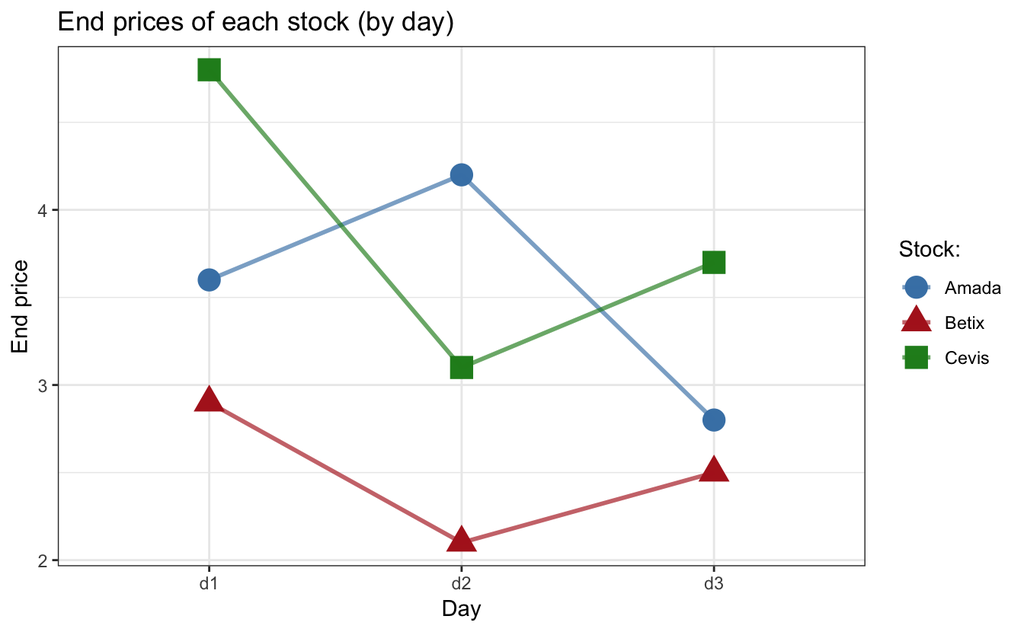

```r
# 3. Plot the end values (on the y-axis) of the 3 stocks over 3 days (x-axis): ----
st_long %>%
  filter(time == "end") %>%
  ggplot(aes(x = day, y = val, color = stock, shape = stock)) +
  geom_point(size = 5) +
  geom_line(aes(group = stock), size = 1, alpha = 2/3) +
  labs(title = "End prices of each stock (by day)",
       x = "Day", y = "End price",
       shape = "Stock:", color = "Stock:") +
  scale_color_manual(values = c("steelblue", "firebrick", "forestgreen")) +
  theme_bw()

# 4. Change st_long into a wider format that lists start and end as 2 distinct variables (columns): ----
st_long %>%
  spread(key = time, value = val) %>%
  mutate(day_nr = parse_integer(str_sub(day, 2, 2))) # optional: get day_nr as integer variable
```

## Exercise 3

#### A posPsy tibble reloaded

In [Exercise 3 of WPA05](http://rpository.com/ds4psy/essentials/tibbles.html#exercise-3) of our essentials on [tibbles](http://rpository.com/ds4psy/essentials/tibbles.html) you created a tibble of mean depression scores (`my_tbl` and `my_tbl_2`) in 2 different ways (by entering the data directly into R with `tibble()` and by using `dplyr` to compute a summary table from the `posPsy_wide` data).

Table: Mean depression scores by intervention and occasion.

| intervention | mn_cesd_0 | mn_cesd_1 | mn_cesd_2 | mn_cesd_3 | mn_cesd_4 | mn_cesd_5 |
| --- | --- | --- | --- | --- | --- | --- |
| 1 | 15.1 | 15.3 | 13.6 | 12.0 | 11.2 | 13.5 |
| 2 | 16.2 | 14.6 | 11.4 | 12.5 | 13.4 | 14.6 |
| 3 | 16.1 | 12.3 | 14.8 | 13.9 | 14.9 | 13.0 |
| 4 | 12.8 | 9.9 | 9.5 | 9.1 | 7.7 | 10.2 |

When trying to create a plot that shows the trends of mean depression scores (over different occasions by intervention) we noted that it is impossible to directly plot the values of `my_tbl_2`. For plotting the mean depression scores with `ggplot` we would need these scores as 1 dependent variable, rather than as 6 different variables.

Earlier, we solved this problem by creating an alternative tibble `my_tbl_3` – which expressed `mean_cesd` as a function of `occasion` and `intervention` (in long format) – from the raw data in `posPsy_long`. Given our new skills in `tidyr`, we now are in a position to transform `my_tbl_2` (or `my_tbl`) into the required format of `my_tbl_3`. Thus, your task is:

1. Re-create one of the original tibbles (either `my_tbl` or `my_tbl_2`) and use `tidyr` to transform it into the long format of `my_tbl_3`.

```r
# Load data: ----
posPsy_wide <- read_csv(file = "http://rpository.com/ds4psy/data/posPsy_data_wide.csv")
# dim(posPsy_wide)  # 295 294

# Re-create tibble: ----
my_tbl_2 <- posPsy_wide %>%
  group_by(intervention) %>%
  summarise(mn_cesd_0 = round(mean(cesdTotal.0, na.rm = TRUE), 1),
            mn_cesd_1 = round(mean(cesdTotal.1, na.rm = TRUE), 1),
            mn_cesd_2 = round(mean(cesdTotal.2, na.rm = TRUE), 1),
            mn_cesd_3 = round(mean(cesdTotal.3, na.rm = TRUE), 1),
            mn_cesd_4 = round(mean(cesdTotal.4, na.rm = TRUE), 1),
            mn_cesd_5 = round(mean(cesdTotal.5, na.rm = TRUE), 1) )
# my_tbl_2

# Transform from wide into long format: ----
my_tbl_3 <- my_tbl_2 %>%
  gather(key = "key", value = "mean_cesd", mn_cesd_0:mn_cesd_5) %>%
  separate(key, c("mn", "cesd", "occasion"), sep = "_") %>%
  select(occasion, intervention, mean_cesd)
# my_tbl_3

# Change some variable types:
my_tbl_3$occasion     <- as.integer(my_tbl_3$occasion)    # as integer
my_tbl_3$intervention <- as.factor(my_tbl_3$intervention) # as factor

# Check:
my_tbl_3
```

```
#> # A tibble: 24 x 3
#>    occasion intervention mean_cesd
#>       <int> <fct>            <dbl>
#>  1        0 1                 15.1
#>  2        0 2                 16.2
#>  3        0 3                 16.1
#>  4        0 4                 12.8
#>  5        1 1                 15.3
#>  6        1 2                 14.6
#>  7        1 3                 12.3
#>  8        1 4                  9.9
#>  9        2 1                 13.6
#> 10        2 2                 11.4
#> # … with 14 more rows
```

```r
my_tbl_4 <- my_tbl_3 %>%
  spread(key = occasion, value = mean_cesd)
my_tbl_4
```

```
#> # A tibble: 4 x 7
#>   intervention   `0`   `1`   `2`   `3`   `4`   `5`
#>   <fct>        <dbl> <dbl> <dbl> <dbl> <dbl> <dbl>
#> 1 1             15.1  15.3  13.6  12    11.2  13.5
#> 2 2             16.2  14.6  11.4  12.5  13.4  14.6
#> 3 3             16.1  12.3  14.8  13.9  14.9  13
#> 4 4             12.8   9.9   9.5   9.1   7.7  10.2
```

```r
# Change names of some variables (columns 2:7):
names(my_tbl_4)[2:ncol(my_tbl_4)] <- paste0("mn_cesd_", names(my_tbl_4)[2:ncol(my_tbl_4)])

# Change some variable types:
my_tbl_4$intervention <- as.double(my_tbl_4$intervention) # back to number

## Verify equality:
# my_tbl_4
# my_tbl_2
all.equal(my_tbl_4, my_tbl_2)
```

```
#> [1] TRUE
```

## Exercise 4

In previous sessions, we have seen 2 sets of data for the [positive psychology](http://rpository.com/ds4psy/essentials/datasets.html#positive-psychology) experiment:

- `posPsy_AHI_CESD_corrected.csv` (990 x 50 variables):  
  http://rpository.com/ds4psy/data/posPsy_AHI_CESD_corrected.csv.
- `posPsy_data_wide.csv` (295 x 294 variables):  
  http://rpository.com/ds4psy/data/posPsy_data_wide.csv.

Both of these datasets contain the same information, but one is in long format and one in wide format. With `tidyr`, we are able to transform the long format into wide format (and vice versa) on our own.

#### 1. From long to wide

Load the file `posPsy_AHI_CESD_corrected.csv` into a tibble `posPsy_long`. To make things simpler, drop all columns except `id`, `occasion`, `intervention`, and `ahiTotal`.

Transform the resulting table from long to wide format (spreading `ahiTotal` values over different `occasion`s).

```r
## Load data: ----
posPsy_long <- read_csv(file = "http://rpository.com/ds4psy/data/posPsy_AHI_CESD_corrected.csv")  # online
dim(posPsy_long)  # 990 x 50
```

```
#> [1] 990  50
```

```r
## Drop most colums: ----
df_long <- posPsy_long %>%
  select(id, occasion, intervention, ahiTotal)
## Check:
# df_long
dim(df_long)  # 990 x 4
```

```
#> [1] 990   4
```

```r
## Spread to wide format: ----
df_wide <- df_long %>%
  spread(occasion, ahiTotal, convert = TRUE)

## Check:
dim(df_wide)  # 295 x 8
```

```
#> [1] 295   8
```

```r
# Fix some variable names:
names(df_wide)[3:8] <- paste0("occ_", names(df_wide)[3:8])

## Check:
df_wide
```

```
#> # A tibble: 295 x 8
#>       id intervention occ_0 occ_1 occ_2 occ_3 occ_4 occ_5
#>    <dbl>        <dbl> <int> <int> <int> <int> <int> <int>
#>  1     1            4    63    73    NA    NA    NA    NA
#>  2     2            1    73    89    89    93    80    77
#>  3     3            4    77    NA    85    NA    NA    NA
#>  4     4            3    60    67    NA    56    61    NA
#>  5     5            2    41    41    47    47    47    NA
#>  6     6            1    62    NA    67    66    NA    NA
#>  7     7            3    67    NA    NA    NA    NA    NA
#>  8     8            2    59    45    38    48    43    NA
#>  9     9            1    48    NA    NA    NA    NA    NA
#> 10    10            2    58    NA    NA    NA    NA    NA
#> # … with 285 more rows
```

#### 2. From wide to long

Load the file `posPsy_data_wide.csv` into a tibble `posPsy_wide` and drop all variables that contain values of individual happiness or depression items (i.e., all score variables *not* containing “Total” in their names).

Then transform this wide format tibble into long format. Your result table should contain all demographic information (in separate columns), the type of scale (ahiTotal vs. cesdTotal), number of `occasion` (0 to 5), and the scale `value` (as dependent variable).

**Hint**: First gather all `Total` variables into a single `value` variable, then separate the key column into 2 variables `scale` and `occasion`.

```r
## Load data: ----
posPsy_wide <- read_csv(file = "http://rpository.com/ds4psy/data/posPsy_data_wide.csv")  # online
dim(posPsy_wide)  # 295 x 294
```

```
#> [1] 295 294
```

```r
## Drop unnecessary columns and gather: ----
df_long <- posPsy_wide %>%
  # drop unnecessary columns:
  select(id, intervention, sex, age, educ, income, contains("Total")) %>%
  gather(-id, -intervention, -sex, -age, -educ, -income,
         key = "score.occasion",
         value = "value")
## Check:
dim(df_long)  # 3540 x 8
```

```
#> [1] 3540    8
```

```r
# df_long

## Separate key column score.occasion: ----
df_long <- df_long %>%
  separate(score.occasion,
           into = c("scale", "occasion"))
## Check:
dim(df_long)  # 3540 x 9
```

```
#> [1] 3540    9
```

```r
# df_long

# Fix some variables:
df_long$occasion <- as.integer(df_long$occasion)

df_long
```

```
#> # A tibble: 3,540 x 9
#>       id intervention   sex   age  educ income scale    occasion value
#>    <dbl>        <dbl> <dbl> <dbl> <dbl>  <dbl> <chr>       <int> <dbl>
#>  1     1            4     2    35     5      3 ahiTotal        0    63
#>  2     2            1     1    59     1      1 ahiTotal        0    73
#>  3     3            4     1    51     4      3 ahiTotal        0    77
#>  4     4            3     1    50     5      2 ahiTotal        0    60
#>  5     5            2     2    58     5      2 ahiTotal        0    41
#>  6     6            1     1    31     5      1 ahiTotal        0    62
#>  7     7            3     1    44     5      2 ahiTotal        0    67
#>  8     8            2     1    57     4      2 ahiTotal        0    59
#>  9     9            1     1    36     4      3 ahiTotal        0    48
#> 10    10            2     1    45     4      3 ahiTotal        0    58
#> # … with 3,530 more rows
```

## Exercise 5

This exercise relies on the main dataset for the [false positive psychology](http://rpository.com/ds4psy/essentials/datasets.html#false-positive-psychology) project:

- `falsePosPsy_all` (78 x 19 variables): http://rpository.com/ds4psy/data/falsePosPsy_all.csv

```r
# Import the Dataset
falsePosPsy_all <- read_csv(file = "http://rpository.com/ds4psy/data/falsePosPsy_all.csv")  # online

## Check:
# dim(falsePosPsy_all)  # 78 x 19
# str(falsePosPsy)

# Working with a copy:
df <- falsePosPsy_all
```

#### Parents age?

1. Plot the relationship between the age of each participant’s `dad` and `mom` (e.g., as a scatterplot).

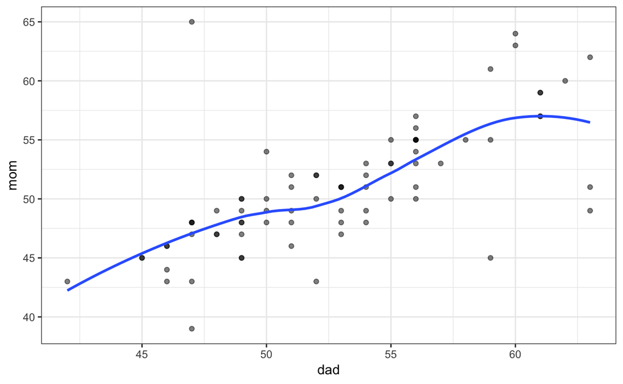

```r
ggplot(df, aes(x = dad, y = mom)) +
  geom_point(alpha = 1/2) +
  geom_smooth(se = FALSE) +
  theme_bw()
```

2. Plot how many moms resp. dads are have which age (i.e., the distributions of age values among moms vs. dads) using `geom_bar`.

(**Hint**: As both ages are in 2 separate variables, you need to use `gather` to collect the ages of both parents in 1 variable.)

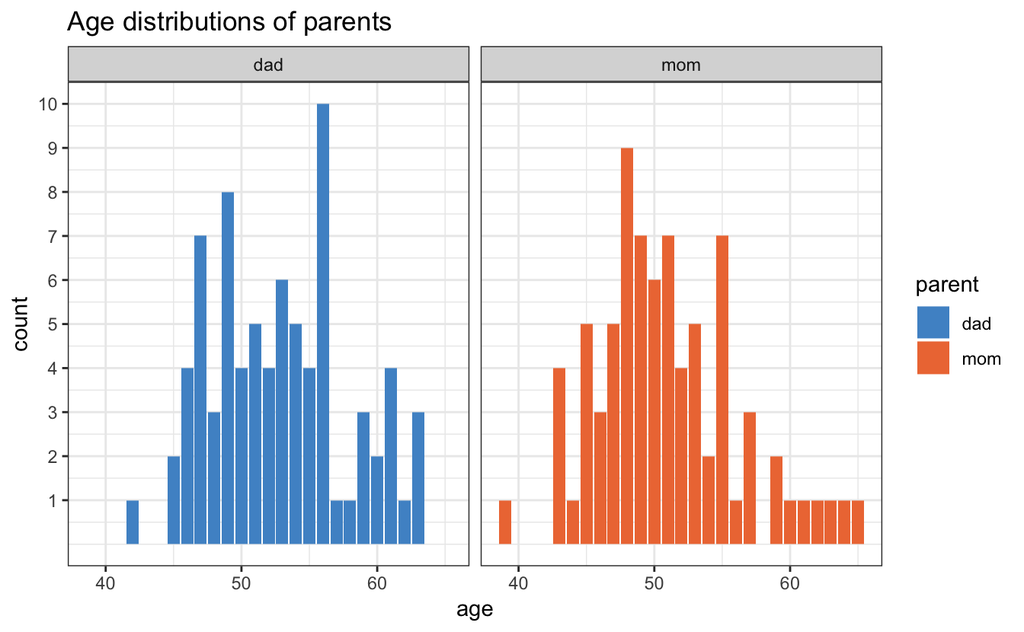

```r
df %>%
  gather(key = "parent", value = "age", dad, mom) %>%
  select(study:aged365, parent, age) %>%
  ggplot(aes(x = age, fill = parent)) +
  geom_bar(position = "dodge") +
  facet_wrap(~parent) +
  scale_y_continuous(limits = c(0, 10),
                     breaks = c(1:10)) +
  labs(title = "Age distributions of parents") +
  scale_fill_manual(values = c("steelblue3", "sienna2")) +
  theme_bw()
```

3. Can you think of a way of plotting the relationship between (or difference between) the age of both parents for each participant?

(**Hint**: Again, you need to use `gather` to collect the ages of both parents into 1 variable.)

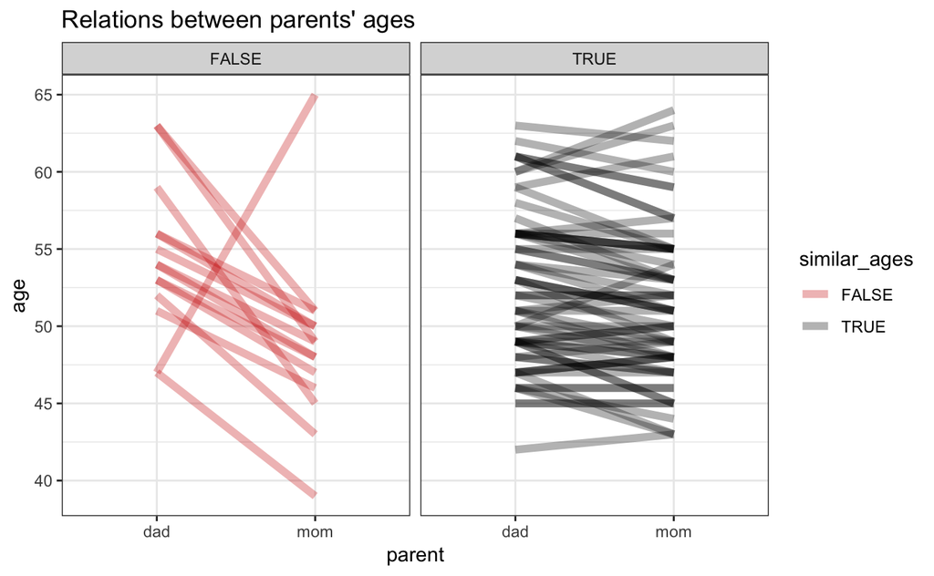

```r
df_long <- df %>%
  mutate(similar_ages = (abs(dad - mom) < 5)) %>%  # similar_ages if difference below 5 years
  select(study:mom, similar_ages) %>%
  gather(key = "parent", value = "age", dad:mom)
# df_long

ggplot(df_long, aes(x = parent, y = age)) +
  geom_line(aes(group = ID, color = similar_ages), alpha = .3, size = 2) +
  facet_grid(~similar_ages) +
  labs(title = "Relations between parents' ages") +
  scale_color_manual(values = c("red3", "black")) +
  theme_bw()
```

We see that most parents are of a similar age (i.e., have an age difference smaller than 5 years). Of the parents with larger age differences it is mostly the dads older than the moms, except for one case in the other direction.

## Exercise 6: Bonus task

This task consists in transforming a data with multiple dependent variables into tidy data. It is considered a bonus task, as this goes beyond the scope of the current chapter, but can be solved with our current base R and `tidyverse` commands.

#### Data

The data table [exp_wide](http://rpository.com/ds4psy/data/exp_wide.csv) contains data from $n = 10$ participants. Each participant completed 2 tasks (and the task position `p` was randomized). For each task, we measured 2 dependent variables: The correctness `c` of the response, and the time `t` (in msec) to complete the task:

Example data from an experiment containing 2 tasks (and 2 DVs).

| subj | p_1 | p_2 | c_1 | c_2 | t_1 | t_2 |
| --- | --- | --- | --- | --- | --- | --- |
| 1 | 1 | 2 | FALSE | FALSE | 4873.7 | 9230.0 |
| 2 | 1 | 2 | FALSE | FALSE | 3963.9 | 2948.8 |
| 3 | 2 | 1 | FALSE | TRUE | 2868.4 | 8348.3 |
| 4 | 2 | 1 | FALSE | FALSE | 2561.3 | 1290.2 |
| 5 | 1 | 2 | TRUE | FALSE | 5762.2 | 9330.7 |
| 6 | 1 | 2 | FALSE | FALSE | 4873.7 | 9230.0 |
| 7 | 2 | 1 | FALSE | TRUE | 3963.9 | 2948.8 |
| 8 | 1 | 2 | TRUE | TRUE | 2868.4 | 8348.3 |
| 9 | 2 | 1 | TRUE | TRUE | 2561.3 | 1290.2 |
| 10 | 2 | 1 | TRUE | FALSE | 5762.2 | 9330.7 |

#### Tasks

1. Import the data from http://rpository.com/ds4psy/data/exp_wide.csv into a tibble `exp_wide`.
2. Use 2 different ways to transform (or reshape) `exp_wide` into a table of tidy data `exp_tidy`.
3. Verify the equality of both solutions.

#### Solutions

1. Solution 1 by using `reshape`:

```r
## Load data: ----
exp_wide <- read_csv(file = "http://rpository.com/ds4psy/data/exp_wide.csv")  # online
dim(exp_wide)  # 10 x 7
```

```
#> [1] 10  7
```

```r
exp_wide
```

```
#> # A tibble: 10 x 7
#>     subj   p_1   p_2 c_1   c_2     t_1   t_2
#>    <dbl> <dbl> <dbl> <lgl> <lgl> <dbl> <dbl>
#>  1     1     1     2 FALSE FALSE 4874. 9230
#>  2     2     1     2 FALSE FALSE 3964. 2949.
#>  3     3     2     1 FALSE TRUE  2868. 8348.
#>  4     4     2     1 FALSE FALSE 2561. 1290.
#>  5     5     1     2 TRUE  FALSE 5762. 9331.
#>  6     6     1     2 FALSE FALSE 4874. 9230
#>  7     7     2     1 FALSE TRUE  3964. 2949.
#>  8     8     1     2 TRUE  TRUE  2868. 8348.
#>  9     9     2     1 TRUE  TRUE  2561. 1290.
#> 10    10     2     1 TRUE  FALSE 5762. 9331.
```

```r
## Use reshape to transform into long format:
exp_long <- reshape(data = exp_wide,
                    direction = "long",
                    varying = list(p = 2:3, # 1st set of variables to combine into 1
                                   c = 4:5, # 2nd set of variables to combine into 1
                                   t = 6:7),
                    v.names = c("position", "correct", "time")
)

exp_tidy_1 <- exp_long %>%
  select(subj, position, correct, time) %>%
  arrange(subj, position)

exp_tidy_1
```

```
#> # A tibble: 20 x 4
#>     subj position correct  time
#>    <dbl>    <dbl> <lgl>   <dbl>
#>  1     1        1 FALSE   4874.
#>  2     1        2 FALSE   9230
#>  3     2        1 FALSE   3964.
#>  4     2        2 FALSE   2949.
#>  5     3        1 TRUE    8348.
#>  6     3        2 FALSE   2868.
#>  7     4        1 FALSE   1290.
#>  8     4        2 FALSE   2561.
#>  9     5        1 TRUE    5762.
#> 10     5        2 FALSE   9331.
#> 11     6        1 FALSE   4874.
#> 12     6        2 FALSE   9230
#> 13     7        1 TRUE    2949.
#> 14     7        2 FALSE   3964.
#> 15     8        1 TRUE    2868.
#> 16     8        2 TRUE    8348.
#> 17     9        1 TRUE    1290.
#> 18     9        2 TRUE    2561.
#> 19    10        1 FALSE   9331.
#> 20    10        2 TRUE    5762.
```

2. Solution 2 by using `tidyverse` commands:

```r
## Load data: ----
exp_wide <- read_csv(file = "http://rpository.com/ds4psy/data/exp_wide.csv")  # online
dim(exp_wide)  # 10 x 7
```

```
#> [1] 10  7
```

```r
exp_wide
```

```
#> # A tibble: 10 x 7
#>     subj   p_1   p_2 c_1   c_2     t_1   t_2
#>    <dbl> <dbl> <dbl> <lgl> <lgl> <dbl> <dbl>
#>  1     1     1     2 FALSE FALSE 4874. 9230
#>  2     2     1     2 FALSE FALSE 3964. 2949.
#>  3     3     2     1 FALSE TRUE  2868. 8348.
#>  4     4     2     1 FALSE FALSE 2561. 1290.
#>  5     5     1     2 TRUE  FALSE 5762. 9331.
#>  6     6     1     2 FALSE FALSE 4874. 9230
#>  7     7     2     1 FALSE TRUE  3964. 2949.
#>  8     8     1     2 TRUE  TRUE  2868. 8348.
#>  9     9     2     1 TRUE  TRUE  2561. 1290.
#> 10    10     2     1 TRUE  FALSE 5762. 9331.
```

```r
## Gather all 6 dependent variables (from wide into long format): --------
exp_long <- exp_wide %>%
  gather(key = "key", value = "value", p_1:t_2) %>%
  separate(col = key, into = c("var", "pos"))
exp_long
```

```
#> # A tibble: 60 x 4
#>     subj var   pos   value
#>    <dbl> <chr> <chr> <dbl>
#>  1     1 p     1         1
#>  2     2 p     1         1
#>  3     3 p     1         2
#>  4     4 p     1         2
#>  5     5 p     1         1
#>  6     6 p     1         1
#>  7     7 p     1         2
#>  8     8 p     1         1
#>  9     9 p     1         2
#> 10    10 p     1         2
#> # … with 50 more rows
```

```r
## Deal with 3 sub-tables (of different DVs): --------

# 1st slice of 20 rows: Position information
exp_pos <- exp_long %>%
  filter(var == "p") %>%   # filter 20 rows with position info
  select(subj, pos, value) %>%
  rename(position = value) %>%
  arrange(subj, pos)  # ensure order
exp_pos
```

```
#> # A tibble: 20 x 3
#>     subj pos   position
#>    <dbl> <chr>    <dbl>
#>  1     1 1            1
#>  2     1 2            2
#>  3     2 1            1
#>  4     2 2            2
#>  5     3 1            2
#>  6     3 2            1
#>  7     4 1            2
#>  8     4 2            1
#>  9     5 1            1
#> 10     5 2            2
#> 11     6 1            1
#> 12     6 2            2
#> 13     7 1            2
#> 14     7 2            1
#> 15     8 1            1
#> 16     8 2            2
#> 17     9 1            2
#> 18     9 2            1
#> 19    10 1            2
#> 20    10 2            1
```

```r
# 2nd slice of 20 rows: Correctness information
exp_cor <- exp_long %>%
  filter(var == "c") %>%  # filter 20 rows with correctness info
  select(subj, pos, value) %>%
  mutate(correct = as.logical(value)) %>%  # correct as Boolean value!
  select(subj, pos, correct) %>%
  arrange(subj, pos)  # ensure order
exp_cor
```

```
#> # A tibble: 20 x 3
#>     subj pos   correct
#>    <dbl> <chr> <lgl>
#>  1     1 1     FALSE
#>  2     1 2     FALSE
#>  3     2 1     FALSE
#>  4     2 2     FALSE
#>  5     3 1     FALSE
#>  6     3 2     TRUE
#>  7     4 1     FALSE
#>  8     4 2     FALSE
#>  9     5 1     TRUE
#> 10     5 2     FALSE
#> 11     6 1     FALSE
#> 12     6 2     FALSE
#> 13     7 1     FALSE
#> 14     7 2     TRUE
#> 15     8 1     TRUE
#> 16     8 2     TRUE
#> 17     9 1     TRUE
#> 18     9 2     TRUE
#> 19    10 1     TRUE
#> 20    10 2     FALSE
```

```r
# 3rd slice of 20 rows: Time information
exp_time <- exp_long %>%
  filter(var == "t") %>%
  select(subj, pos, value) %>%
  mutate(time = as.numeric(value)) %>%  # time as numeric value!
  select(subj, pos, time) %>%
  arrange(subj, pos)  # ensure order
exp_time
```

```
#> # A tibble: 20 x 3
#>     subj pos    time
#>    <dbl> <chr> <dbl>
#>  1     1 1     4874.
#>  2     1 2     9230
#>  3     2 1     3964.
#>  4     2 2     2949.
#>  5     3 1     2868.
#>  6     3 2     8348.
#>  7     4 1     2561.
#>  8     4 2     1290.
#>  9     5 1     5762.
#> 10     5 2     9331.
#> 11     6 1     4874.
#> 12     6 2     9230
#> 13     7 1     3964.
#> 14     7 2     2949.
#> 15     8 1     2868.
#> 16     8 2     8348.
#> 17     9 1     2561.
#> 18     9 2     1290.
#> 19    10 1     5762.
#> 20    10 2     9331.
```

```r
## Combine all 3 sub-tables again: --------
exp_pos_cor      <- left_join(exp_pos, exp_cor)
exp_pos_cor_time <- left_join(exp_pos_cor, exp_time)

# Select and arrange:
exp_tidy_2 <- exp_pos_cor_time %>%
  select(subj, position, correct, time) %>%
  arrange(subj, position)

exp_tidy_2
```

```
#> # A tibble: 20 x 4
#>     subj position correct  time
#>    <dbl>    <dbl> <lgl>   <dbl>
#>  1     1        1 FALSE   4874.
#>  2     1        2 FALSE   9230
#>  3     2        1 FALSE   3964.
#>  4     2        2 FALSE   2949.
#>  5     3        1 TRUE    8348.
#>  6     3        2 FALSE   2868.
#>  7     4        1 FALSE   1290.
#>  8     4        2 FALSE   2561.
#>  9     5        1 TRUE    5762.
#> 10     5        2 FALSE   9331.
#> 11     6        1 FALSE   4874.
#> 12     6        2 FALSE   9230
#> 13     7        1 TRUE    2949.
#> 14     7        2 FALSE   3964.
#> 15     8        1 TRUE    2868.
#> 16     8        2 TRUE    8348.
#> 17     9        1 TRUE    1290.
#> 18     9        2 TRUE    2561.
#> 19    10        1 FALSE   9331.
#> 20    10        2 TRUE    5762.
```

3. Verify the equality of both solutions:

```r
all.equal(exp_tidy_1, exp_tidy_2)  # TRUE (qed).
```

```
#> [1] TRUE
```

# More on tidy data

- Study the vignette on `vignette("tidy-data")` and the [RStudio cheatsheet](https://www.rstudio.com/resources/cheatsheets/) on *Data Import* for essential `tidyr` commands.
- Read [Chapter 12: Tidy data](http://r4ds.had.co.nz/tidy-data.html) and complete its exercises.
- For background information on the notion of tidy data, see  
  Wickham, H. (2014). Tidy data. *Journal of Statistical Software*, *59*(10), 1–23.  
  available at http://www.jstatsoft.org/v59/i10/paper.
- Follow the links on https://tidyr.tidyverse.org. for additional information.

# Conclusion

All [ds4psy](http://rpository.com/ds4psy/) essentials so far:

| Nr. | Topic |
| --- | --- |
| 0. | [Syllabus](http://rpository.com/ds4psy/) |
| 1. | [Basic R concepts and commands](http://rpository.com/ds4psy/essentials/basics.html) |
| 2. | [Visualizing data](http://rpository.com/ds4psy/essentials/visualize.html) |
| 3. | [Transforming data](http://rpository.com/ds4psy/essentials/transform.html) |
| 4. | [Exploring data (EDA)](http://rpository.com/ds4psy/essentials/explore.html) |
| 5. | [Tibbles](http://rpository.com/ds4psy/essentials/tibbles.html) |
| 6. | [Importing data](http://rpository.com/ds4psy/essentials/import.html) |
| 7. | **Tidying data** [*](http://rpository.com/ds4psy/essentials/tidy.html) |
| 8. | [Joining data](http://rpository.com/ds4psy/essentials/join.html) |
| 9. | [Functions](http://rpository.com/ds4psy/essentials/function.html) |
| 10. | [Iteration](http://rpository.com/ds4psy/essentials/iteration.html) |
| +. | [Datasets](http://rpository.com/ds4psy/essentials/datasets.html) |

[Last update on 2019-05-22 11:48:39 by [hn](http://neth.de/).]

[^1]: The length and width of a data set are relative terms here: gathering tends to decrease data width by increasing length, spreading tends to decrease data length by increasing width.
[^2]: Again, the length and width of data sets are relative terms.